# Exploratory Analysis

Kevin Siswandi

19 March 2016

# Overview

In this report, an exploratory analysis of the three datasets in English language, namely en_US.blogs.txt, en_US.twitter.txt and en_US.news.txt, is performed. The analysis includes basic summaries of the three datasets and frequency count in the form of wordcloud. Packages used in this report are tm, wordcloud, RColorBrewer and SnowballC (required by tm).

# Getting data

```r
#store as character
blog.char <- scan("/home/kevins/swiftkey/final/en_US/en_US.blogs.txt", what="character")
tweet.char <- scan("/home/kevins/swiftkey/final/en_US/en_US.twitter.txt", what="character")
news.char <- scan("/home/kevins/swiftkey/final/en_US/en_US.news.txt", what="character")

#store as list of lines
blog.con <- file("/home/kevins/swiftkey/final/en_US/en_US.blogs.txt", "r")
blog.lines <- readLines(blog.con)
tweet.con <- file("/home/kevins/swiftkey/final/en_US/en_US.twitter.txt", "r")
tweet.lines <- readLines(tweet.con)
news.con <- file("/home/kevins/swiftkey/final/en_US/en_US.news.txt", "r")
news.lines <- readLines(news.con)
```

# Exploratory Analysis

Basic summaries: word count, line count, and basic tables.

```r
blog.summary <- c(length(blog.char), length(blog.lines))
tweet.summary <- c(length(tweet.char), length(tweet.lines))
news.summary <- c(length(news.char), length(news.lines))
summaries <- rbind(blog.summary, tweet.summary, news.summary)
colnames(summaries) <- c("nwords", "nlines")
summaries
```

```
##                 nwords  nlines
## blog.summary  35314175  899288
## tweet.summary  9141409 2360148
## news.summary  29313276 1010242
```

As the data size is big, only a subset of 10,000 lines (randomly sampled) will be used.

```r
rm(blog.char, tweet.char, news.char)

blog.lines <- sample(blog.lines, 10000)
tweet.lines <- sample(tweet.lines, 10000)
news.lines <- sample(news.lines, 10000)

combined.data <- c(blog.lines, tweet.lines, news.lines)
```

Wordcloud

```r
library(tm)
```

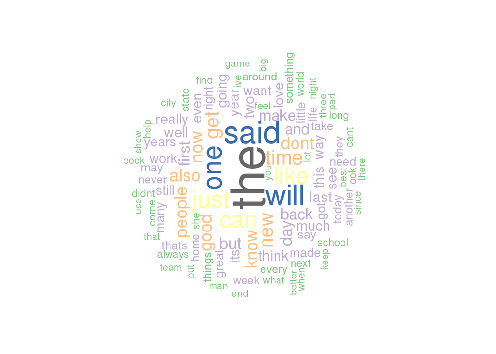

```r
library(wordcloud)
#processing to remove punctuation, stopwords, and perform stemming.
combined.data <- removePunctuation(combined.data)
combined.data <- removeWords(combined.data, c('the', stopwords("english")))
combined.data <- stemDocument(combined.data)

wordcloud(combined.data, max.words=100, random.order=FALSE, rot.per=0.5, colors=brewer.pal(8, 'Accent'))
```

# Plan for the project

A basic text prediction model based on N-gram will be employed. The N-gram model allows one to predict the last word of a sequence of N words given the previous (N-1) words. Given the limitation of hardware and time, a trigram model will likely be chosen to compute the relative frequency of an observed particular three-word sequence to its (two-word) prefix. In other words, the plan is to build a matrix/table of probabilities of trigram counts and make prediction (i.e. the word with the highest probability given the preceding two words) based on the table.